# HMDA_2008_IL_EDA - Initial Analysis for 2007 IL Data

# Data Analysis Section 2: Missing Values

We start by finding the number of NAs in the dataset

```r
sapply(hmda_pa_df,function(x) sum(is.na(x)))
```

```
##                     as_of_year                  respondent_id
##                              0                              0
##                    agency_name                    agency_abbr
##                              0                              0
##                    agency_code                 loan_type_name
##                              0                              0
##                      loan_type             property_type_name
##                              0                              0
##                  property_type              loan_purpose_name
##                              0                              0
##                   loan_purpose           owner_occupancy_name
##                              0                              0
##                owner_occupancy               loan_amount_000s
##                              0                              0
##               preapproval_name                    preapproval
##                              0                              0
##              action_taken_name                   action_taken
##                              0                              0
##                     msamd_name                          msamd
##                              0                         142982
##                     state_name                     state_abbr
##                              0                              0
##                     state_code                    county_name
##                              0                              0
##                    county_code            census_tract_number
##                           3270                           3784
##       applicant_ethnicity_name            applicant_ethnicity
##                              0                              0
##    co_applicant_ethnicity_name         co_applicant_ethnicity
##                              0                              0
##          applicant_race_name_1               applicant_race_1
##                              0                              0
##          applicant_race_name_2               applicant_race_2
##                              0                         990310
##          applicant_race_name_3               applicant_race_3
##                              0                         992730
##          applicant_race_name_4               applicant_race_4
##                              0                         992857
##          applicant_race_name_5               applicant_race_5
##                              0                         992866
```

[output cut: 23 more lines]

```
##                         987486                         919548
##              hoepa_status_name                   hoepa_status
##                              0                              0
##               lien_status_name                    lien_status
##                              0                              0
##               edit_status_name                    edit_status
##                              0                         830669
##                sequence_number                     population
##                              0                           3819
##            minority_population       hud_median_family_income
##                           3828                           3795
##          tract_to_msamd_income number_of_owner_occupied_units
##                           3911                           3926
##  number_of_1_to_4_family_units     application_date_indicator
##                           3854                              0
```

Checking the dattaframe for empty strings

```r
sapply(hmda_pa_df,function(x) sum(x==""))
```

```
##                     as_of_year                  respondent_id
##                              0                              0
##                    agency_name                    agency_abbr
##                              0                              0
##                    agency_code                 loan_type_name
##                              0                              0
##                      loan_type             property_type_name
##                              0                              0
##                  property_type              loan_purpose_name
##                              0                              0
##                   loan_purpose           owner_occupancy_name
##                              0                              0
##                owner_occupancy               loan_amount_000s
##                              0                              0
##               preapproval_name                    preapproval
##                              0                              0
##              action_taken_name                   action_taken
##                              0                              0
##                     msamd_name                          msamd
##                         142982                             NA
##                     state_name                     state_abbr
##                              0                              0
##                     state_code                    county_name
##                              0                           3270
##                    county_code            census_tract_number
##                             NA                             NA
##       applicant_ethnicity_name            applicant_ethnicity
##                              0                              0
##    co_applicant_ethnicity_name         co_applicant_ethnicity
##                              0                              0
##          applicant_race_name_1               applicant_race_1
##                              0                              0
##          applicant_race_name_2               applicant_race_2
##                         990310                             NA
##          applicant_race_name_3               applicant_race_3
##                         992730                             NA
##          applicant_race_name_4               applicant_race_4
##                         992857                             NA
##          applicant_race_name_5               applicant_race_5
##                         992866                             NA
```

[output cut: 23 more lines]

```
##                             NA                             NA
##              hoepa_status_name                   hoepa_status
##                              0                              0
##               lien_status_name                    lien_status
##                              0                              0
##               edit_status_name                    edit_status
##                         830669                             NA
##                sequence_number                     population
##                              0                             NA
##            minority_population       hud_median_family_income
##                             NA                             NA
##          tract_to_msamd_income number_of_owner_occupied_units
##                             NA                             NA
##  number_of_1_to_4_family_units     application_date_indicator
##                             NA                              0
```

Check for missing values present as ?

```r
sapply(hmda_pa_df,function(x) sum(x=="?"))
```

```
##                     as_of_year                  respondent_id
##                              0                              0
##                    agency_name                    agency_abbr
##                              0                              0
##                    agency_code                 loan_type_name
##                              0                              0
##                      loan_type             property_type_name
##                              0                              0
##                  property_type              loan_purpose_name
##                              0                              0
##                   loan_purpose           owner_occupancy_name
##                              0                              0
##                owner_occupancy               loan_amount_000s
##                              0                              0
##               preapproval_name                    preapproval
##                              0                              0
##              action_taken_name                   action_taken
##                              0                              0
##                     msamd_name                          msamd
##                              0                             NA
##                     state_name                     state_abbr
##                              0                              0
##                     state_code                    county_name
##                              0                              0
##                    county_code            census_tract_number
##                             NA                             NA
##       applicant_ethnicity_name            applicant_ethnicity
##                              0                              0
##    co_applicant_ethnicity_name         co_applicant_ethnicity
##                              0                              0
##          applicant_race_name_1               applicant_race_1
##                              0                              0
##          applicant_race_name_2               applicant_race_2
##                              0                             NA
##          applicant_race_name_3               applicant_race_3
##                              0                             NA
##          applicant_race_name_4               applicant_race_4
##                              0                             NA
##          applicant_race_name_5               applicant_race_5
##                              0                             NA
```

[output cut: 23 more lines]

```
##                             NA                             NA
##              hoepa_status_name                   hoepa_status
##                              0                              0
##               lien_status_name                    lien_status
##                              0                              0
##               edit_status_name                    edit_status
##                              0                             NA
##                sequence_number                     population
##                              0                             NA
##            minority_population       hud_median_family_income
##                             NA                             NA
##          tract_to_msamd_income number_of_owner_occupied_units
##                             NA                             NA
##  number_of_1_to_4_family_units     application_date_indicator
##                             NA                              0
```

Check for NULL values

```r
sapply(hmda_pa_df,function(x) sum(is.null(x)))
```

```
##                     as_of_year                  respondent_id
##                              0                              0
##                    agency_name                    agency_abbr
##                              0                              0
##                    agency_code                 loan_type_name
##                              0                              0
##                      loan_type             property_type_name
##                              0                              0
##                  property_type              loan_purpose_name
##                              0                              0
##                   loan_purpose           owner_occupancy_name
##                              0                              0
##                owner_occupancy               loan_amount_000s
##                              0                              0
##               preapproval_name                    preapproval
##                              0                              0
##              action_taken_name                   action_taken
##                              0                              0
##                     msamd_name                          msamd
##                              0                              0
##                     state_name                     state_abbr
##                              0                              0
##                     state_code                    county_name
##                              0                              0
##                    county_code            census_tract_number
##                              0                              0
##       applicant_ethnicity_name            applicant_ethnicity
##                              0                              0
##    co_applicant_ethnicity_name         co_applicant_ethnicity
##                              0                              0
##          applicant_race_name_1               applicant_race_1
##                              0                              0
##          applicant_race_name_2               applicant_race_2
##                              0                              0
##          applicant_race_name_3               applicant_race_3
##                              0                              0
##          applicant_race_name_4               applicant_race_4
##                              0                              0
##          applicant_race_name_5               applicant_race_5
##                              0                              0
```

[output cut: 23 more lines]

```
##                              0                              0
##              hoepa_status_name                   hoepa_status
##                              0                              0
##               lien_status_name                    lien_status
##                              0                              0
##               edit_status_name                    edit_status
##                              0                              0
##                sequence_number                     population
##                              0                              0
##            minority_population       hud_median_family_income
##                              0                              0
##          tract_to_msamd_income number_of_owner_occupied_units
##                              0                              0
##  number_of_1_to_4_family_units     application_date_indicator
##                              0                              0
```

# Data Analysis Section 3: Analysis on the columns of interest

### Columns having the information about applicants Race and Ethnicity,

Applicants Ethnicity Values

```r
unique(hmda_pa_df$applicant_ethnicity_name)
```

```
## [1] "Not Hispanic or Latino"
## [2] "Not applicable"
## [3] "Information not provided by applicant in mail, Internet, or telephone application"
## [4] "Hispanic or Latino"
```

Applicant Race Encoded Numbers

```r
unique(hmda_pa_df$applicant_race_1)
```

```
## [1] 3 5 7 2 1 6 4
```

Applicant Race Name

```r
unique(hmda_pa_df$applicant_race_name_1)
```

```
## [1] "Black or African American"
## [2] "White"
## [3] "Not applicable"
## [4] "Asian"
## [5] "American Indian or Alaska Native"
## [6] "Information not provided by applicant in mail, Internet, or telephone application"
## [7] "Native Hawaiian or Other Pacific Islander"
```

Distribution of applicants based on their race

```r
hmda_pa_df$applicant_race_and_ethnicity <- NA
hmda_pa_df$co_applicant_race_and_ethnicity <- NA

hmda_pa_df$applicant_race_and_ethnicity <- ifelse(hmda_pa_df$applicant_ethnicity_name == "Hispanic or Latino",
       "Hispanic or Latino", hmda_pa_df$applicant_race_name_1)

hmda_pa_df$co_applicant_race_and_ethnicity <- ifelse(hmda_pa_df$co_applicant_ethnicity_name == "Hispanic or Latino",
       "Hispanic or Latino", hmda_pa_df$co_applicant_race_name_1)

hmda_pa_df$applicant_race_and_ethnicity[hmda_pa_df$applicant_race_and_ethnicity == "Information not provided by applicant in mail, Internet, or telephone application"] <- "No Information Provided"

head(hmda_pa_df)
```

```
##   as_of_year respondent_id                                 agency_name
## 1       2007    0000004410                Office of Thrift Supervision
## 2       2007    0000000148   Office of the Comptroller of the Currency
## 3       2007    05-0402708 Department of Housing and Urban Development
## 4       2007    0000000148   Office of the Comptroller of the Currency
## 5       2007    0000000148   Office of the Comptroller of the Currency
## 6       2007    0000000148   Office of the Comptroller of the Currency
##   agency_abbr agency_code loan_type_name loan_type
## 1         OTS           4   Conventional         1
## 2         OCC           1   Conventional         1
## 3         HUD           7   Conventional         1
## 4         OCC           1   Conventional         1
## 5         OCC           1   Conventional         1
## 6         OCC           1   Conventional         1
##                                              property_type_name property_type
```

[output cut: 167 more lines]

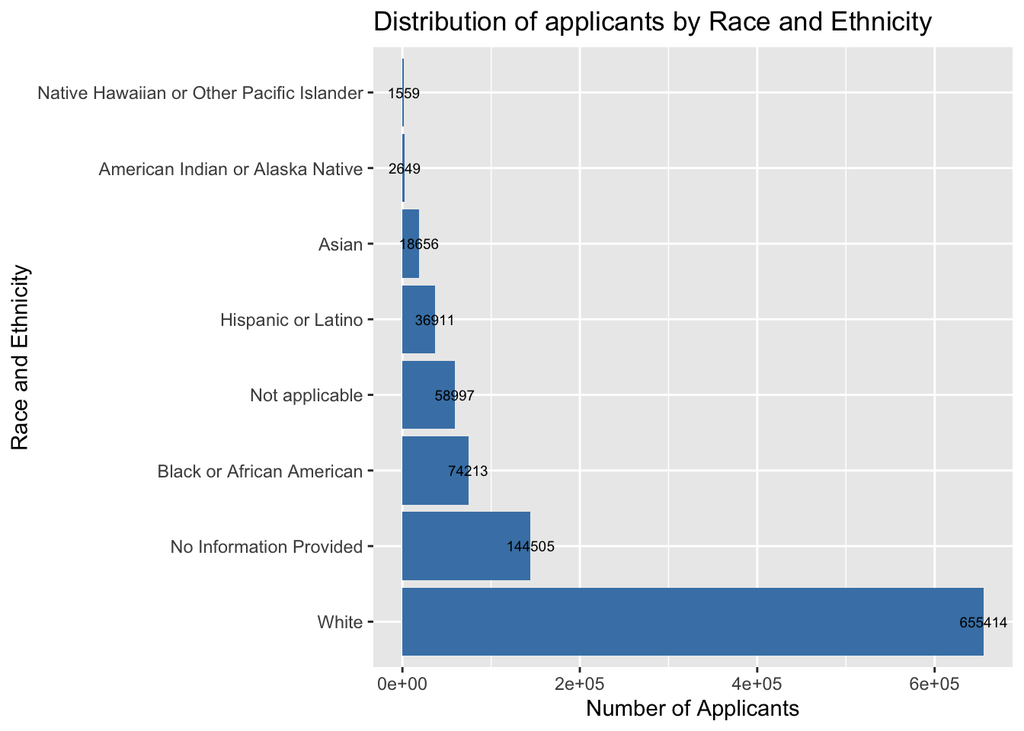

```r
count_racename <- as.data.frame(table(hmda_pa_df$applicant_race_and_ethnicity))
colnames(count_racename)<-c("Race_and_Ethnicity","Count")
p<-ggplot(data=count_racename, aes(x=reorder(Race_and_Ethnicity,-Count), y=Count)) + geom_bar(stat="identity",fill="steelblue")+geom_text(aes(label=Count), size=2.5)
p + coord_flip() +labs(title = "Distribution of applicants by Race and Ethnicity", y="Number of Applicants",x="Race and Ethnicity")
```

The number of white applicants are comparatively higher in the dataset ### Applicants Income

Lets dive into the applicants income

```r
summary(hmda_pa_df$applicant_income_000s)
```

```
##    Min. 1st Qu.  Median    Mean 3rd Qu.    Max.    NA's
##    1.00   42.00   63.00   81.53   94.00 9999.00   62522
```

Here it can be observed that the income of applicants is spreadout a lot. We have applicants with income ranging from 1 to 9999 in thousands. Also, missing values sum upto 62522.

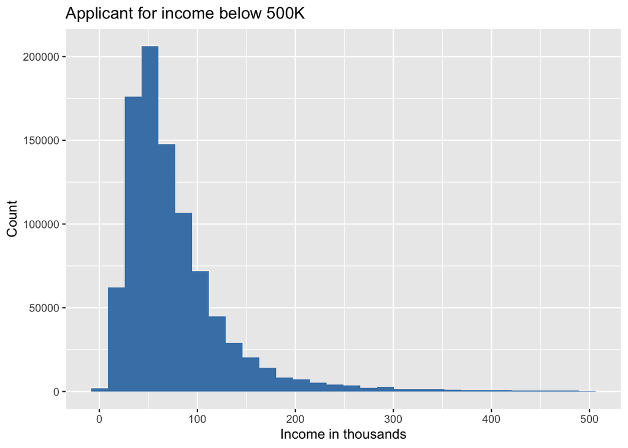

```r
temp<-as.data.frame(hmda_pa_df$applicant_income_000s[hmda_pa_df$applicant_income_000s<500])
ggplot(data = temp, aes(x=hmda_pa_df$applicant_income_000s[hmda_pa_df$applicant_income_000s < 500])) +geom_histogram(fill = "steelblue") + labs(title = "Applicant for income below 500K" , x = "Income in thousands",y="Count")
```

The distribution is right skewed. It would be better if we use median as the measure of central tendency. Lets see what % of applicants have income below 500 from the entire dataset.

```r
no_of_NAs <- sum(is.na(temp))
income_below_500<-length(hmda_pa_df$applicant_income_000s[hmda_pa_df$applicant_income_000s<500])
total_applicants<-length(hmda_pa_df$applicant_income_000s)

((income_below_500 - no_of_NAs ) / total_applicants ) *100
```

```
## [1] 93.16097
```

Approximately 93.16% of the total applicants have income below 500K.

### Applicants according to their race and there median income.

```r
m <- summarise_at(group_by(hmda_pa_df,applicant_race_and_ethnicity),vars(applicant_income_000s),funs(median(.,na.rm=TRUE)))
```

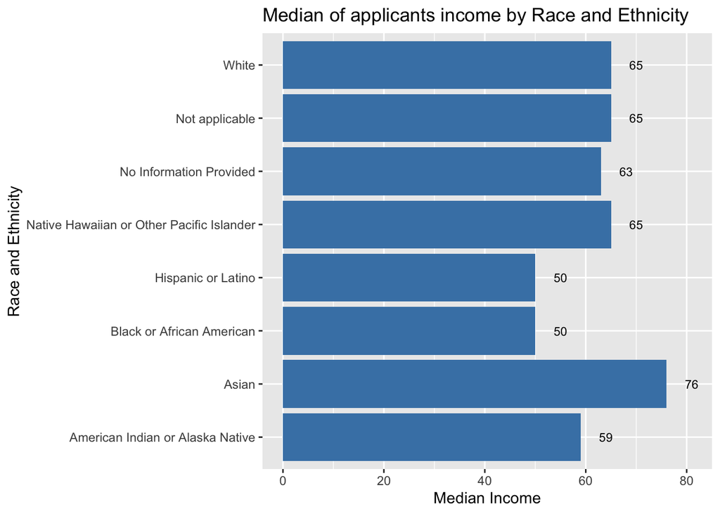

```r
ggplot(data = m ,aes (x =  applicant_race_and_ethnicity,y = applicant_income_000s)) + geom_bar(stat = "identity",fill = "steelblue") +geom_text(aes(label=applicant_income_000s), size=3,nudge_y = 5)+ coord_flip()+labs(title = "Median of applicants income by Race and Ethnicity", y="Median Income",x="Race and Ethnicity")
```

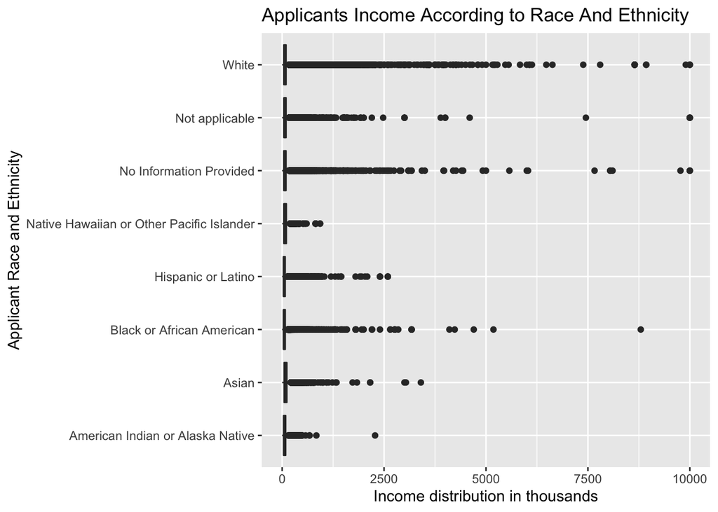

```r
p <- ggplot(group_by(hmda_pa_df,applicant_race_and_ethnicity), aes(x=applicant_race_and_ethnicity, y=applicant_income_000s)) +
  geom_boxplot() + labs(title = "Applicants Income According to Race And Ethnicity" , x = "Applicant Race and Ethnicity" , y = "Income distribution in thousands")
p +coord_flip()
```

### Distribution of income for the originated loans

```r
hmda_origination_status_df <- hmda_pa_df[hmda_pa_df$action_taken == "1", ]
summary(hmda_origination_status_df$applicant_income_000s)
```

```
##    Min. 1st Qu.  Median    Mean 3rd Qu.    Max.    NA's
##    1.00   45.00   67.00   87.01  100.00 9999.00   12842
```

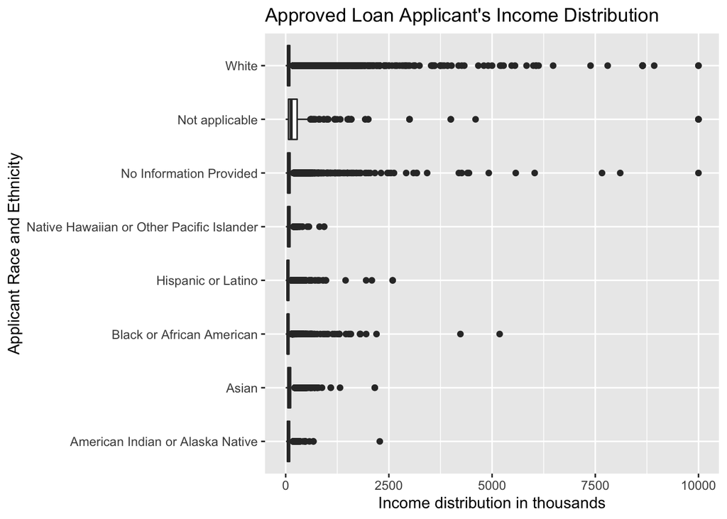

```r
p <- ggplot(group_by(hmda_origination_status_df,applicant_race_and_ethnicity), aes(x=applicant_race_and_ethnicity, y=applicant_income_000s)) +
  geom_boxplot() + labs(title = "Approved Loan Applicant's Income Distribution" , x = "Applicant Race and Ethnicity" , y = "Income distribution in thousands")
p +coord_flip()
```

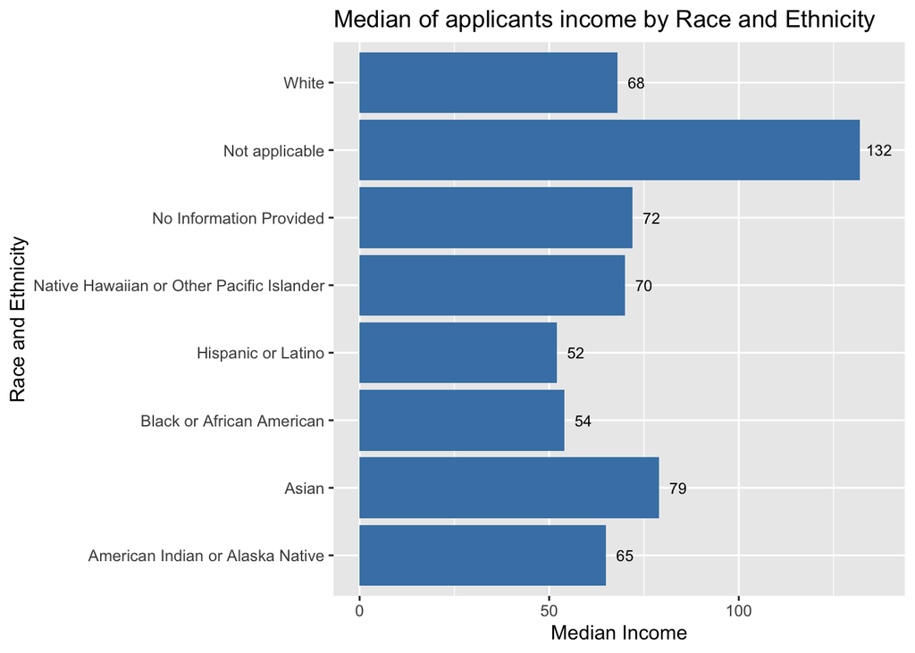

```r
m <- summarise_at(group_by(hmda_origination_status_df,applicant_race_and_ethnicity),vars(applicant_income_000s),funs(median(.,na.rm=TRUE)))
ggplot(data = m ,aes (x =  applicant_race_and_ethnicity,y = applicant_income_000s)) + geom_bar(stat = "identity",fill = "steelblue") +geom_text(aes(label=applicant_income_000s), size=3 , nudge_y = 5)+ coord_flip()+labs(title = "Median of applicants income by Race and Ethnicity", y="Median Income",x="Race and Ethnicity")
```

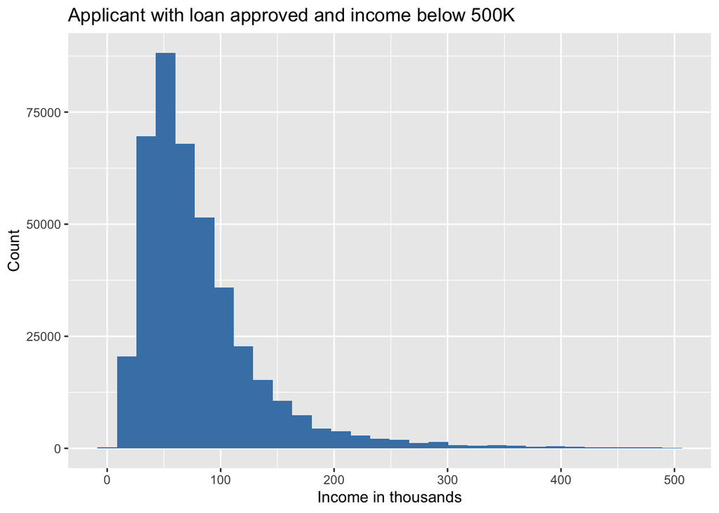

```r
temp<-as.data.frame(hmda_origination_status_df$applicant_income_000s[hmda_origination_status_df$applicant_income_000s<500])

ggplot(data = temp, aes(x=hmda_origination_status_df$applicant_income_000s[hmda_origination_status_df$applicant_income_000s < 500])) +geom_histogram(fill = "steelblue") + labs(title = "Applicant with loan approved and income below 500K" , x = "Income in thousands",y="Count")
```

### Proportion of loans originated

What are the set of decisions made for an application?

```r
unique(hmda_pa_df$action_taken_name)
```

```
## [1] "Loan originated"
## [2] "Application denied by financial institution"
## [3] "Application withdrawn by applicant"
## [4] "File closed for incompleteness"
## [5] "Loan purchased by the institution"
## [6] "Application approved but not accepted"
## [7] "Preapproval request denied by financial institution"
## [8] "Preapproval request approved but not accepted"
```

Here, we can say the loan is denied in two ways. 1. Application denied by financial institution 2. Preapproval request denied by financial institution

The loan is approved if 1. “Application approved but not accepted” 2. “Loan originated”

Other than this, we would classify decision as “Technical or paperwork Issues” 1. “Application withdrawn by applicant” 2. “Loan purchased by the institution 3.”File closed for incompleteness" 4. “Preapproval request approved but not accepted”

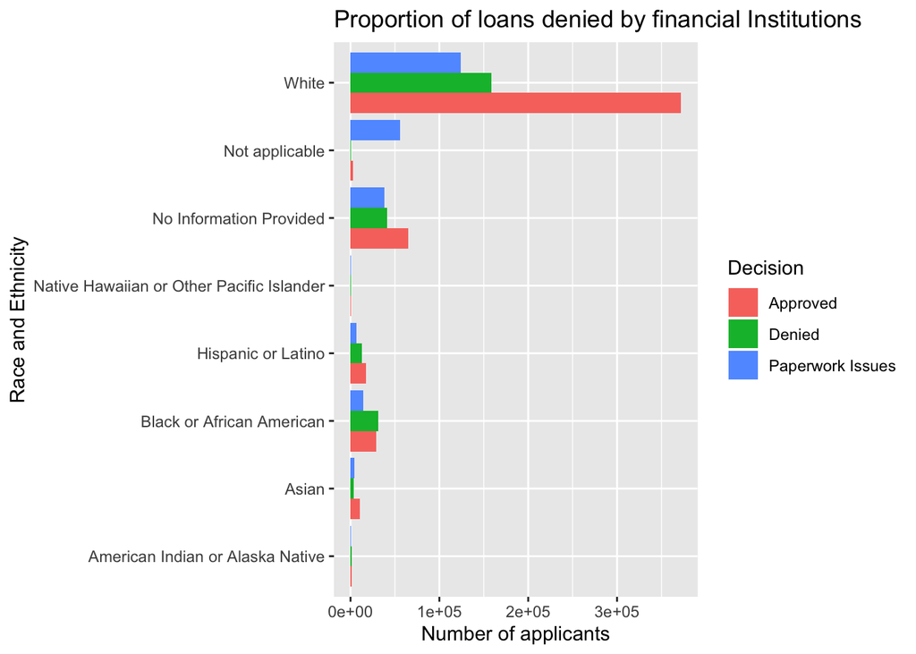

```r
hmda_pa_df$Decision <- NA

hmda_pa_df$Decision <- ifelse(hmda_pa_df$action_taken_name == "Application denied by financial institution" | hmda_pa_df$action_taken_name == "Preapproval request denied by financial institution" , "Denied" ,  ifelse(hmda_pa_df$action_taken_name == "Loan originated" | hmda_pa_df$action_taken_name == "Application approved but not accepted" ,  "Approved" , "Paperwork Issues"))

tbl <- with(hmda_pa_df, table(Decision,applicant_race_and_ethnicity))

ggplot(as.data.frame(tbl), aes(factor(applicant_race_and_ethnicity), Freq, fill = Decision)) +
  geom_col(position = 'dodge') + labs(title = "Proportion of loans denied by financial Institutions",x = "Race and Ethnicity" , y = "Number of applicants") + coord_flip()
```

[figure not shown]

```r
tbl <- with(hmda_pa_df, table(action_taken_name,applicant_race_and_ethnicity))

ggplot(as.data.frame(tbl), aes(factor(applicant_race_and_ethnicity), Freq, fill = action_taken_name)) +
  geom_col(position = 'dodge') + labs(title = "Proportion of loans denied by financial Institutions",x = "Race and Ethnicity" , y = "Number of applicants")
```

```r
mortgage_status_by_race_and_ethnicity <- hmda_pa_df %>% group_by(action_taken_name, applicant_race_and_ethnicity) %>%
  summarise(ActionCount = n()) %>%
  arrange(desc(ActionCount))

mortgage_by_race_and_ethnicity = hmda_pa_df %>% group_by(applicant_race_and_ethnicity) %>%
  summarise(EthnicityCount = n()) %>%
  arrange(desc(EthnicityCount))

mortgage_status_aggregated_by_race_and_ethnicity  = inner_join(mortgage_status_by_race_and_ethnicity, mortgage_by_race_and_ethnicity) %>% mutate(percentage = (ActionCount / EthnicityCount) * 100)
```

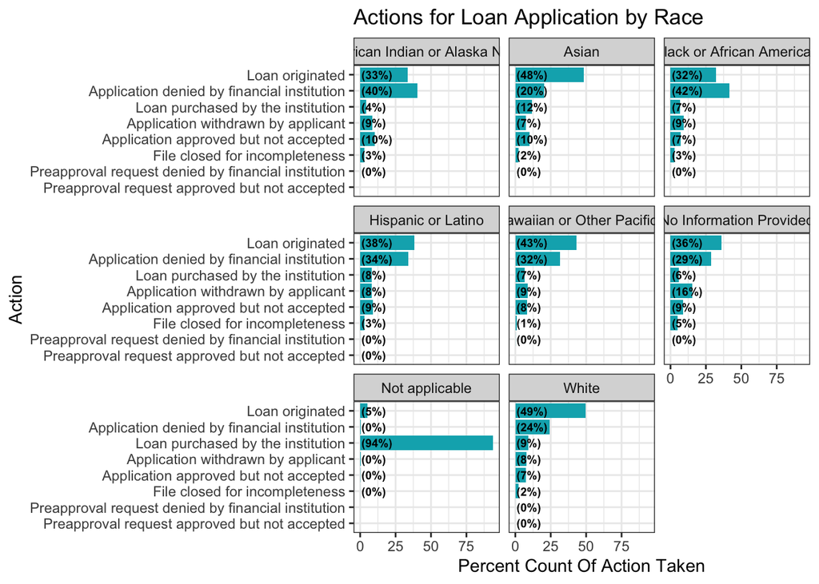

```r
ggplot(mortgage_status_aggregated_by_race_and_ethnicity, aes(x = reorder(action_taken_name, percentage),
                                          y = percentage)) +
  geom_bar(stat='identity', fill ="#00AFBB") +
  facet_wrap(~ applicant_race_and_ethnicity) +
  geom_text(aes(x = action_taken_name, y = 1, label = paste0("(",round(percentage),"%)",sep="")),
            hjust=0, vjust=.5, size = 2.5, colour = 'black',
            fontface = 'bold') +
  labs(x = 'Action', y = 'Percent Count Of Action Taken', title = 'Actions for Loan Application by Race') +
  coord_flip() +
  theme_bw()
```

Some colors which can be used for graphs

```r
cbp2 <- c("#000000", "#E69F00", "#56B4E9", "#009E73",
          "#F0E442", "#0072B2", "#D55E00", "#CC79A7")
```

### Different Type of Loans

```r
unique(hmda_pa_df$loan_type_name)
```

```
## [1] "Conventional"       "FHA-insured"        "VA-guaranteed"
## [4] "FSA/RHS-guaranteed"
```

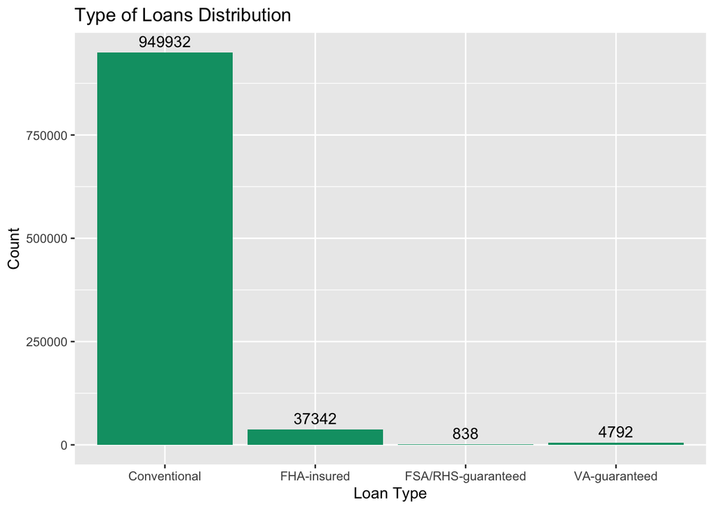

```r
ggplot(data = summarise_at(group_by(hmda_pa_df,loan_type_name),vars(loan_type),funs(n())),aes(x = loan_type_name,y =  loan_type)) + geom_bar(stat = "identity",fill = "#009E73") + geom_text(aes(label = loan_type), vjust = -0.5) +labs(title = "Type of Loans Distribution" , x = "Loan Type" , y = "Count")
```

### Applicants loan amount

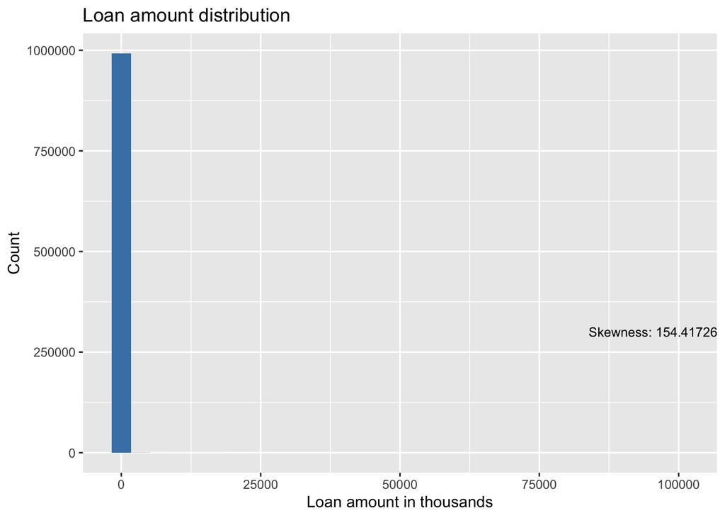

```r
skew <- paste("Skewness:",skewness(hmda_pa_df$loan_amount_000s,na.rm = TRUE))
ggplot(data = hmda_pa_df , aes(x = loan_amount_000s)) + geom_histogram(fill = "steelblue") + labs(title = "Loan amount distribution" , x = "Loan amount in thousands" , y = "Count")+ annotate("text", x = 100000, y = 300000, size = 3.2,label = skew)
```

Looks like the data is highly skewed.

```r
#install.packages("moments")
library(moments)
skewness(hmda_pa_df$loan_amount_000s,na.rm = TRUE)
```

```
## [1] 154.4175
```

The data for loan amount is highly right skewed. Changes should be made so that the prediction model does not mess up.

## Handling highly skewed data. Log Transformation

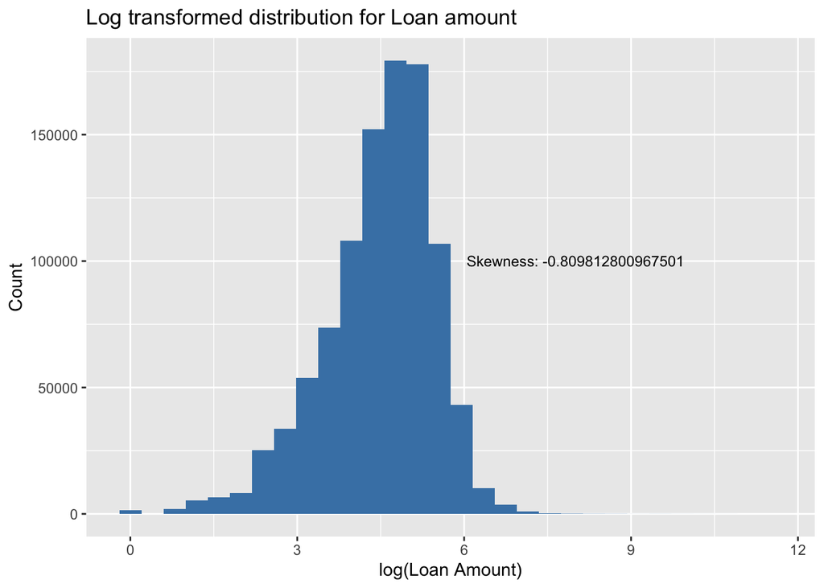

```r
skew <- paste("Skewness:",skewness(log(hmda_pa_df$loan_amount_000s),na.rm = TRUE))
ggplot(data = hmda_pa_df , aes(x = log(loan_amount_000s))) + geom_histogram(fill = "steelblue") + labs(title = "Log transformed distribution for Loan amount" , x = "log(Loan Amount)", y = 'Count')+ annotate("text", x = 8, y = 100000, size = 3.2,label = skew)
```

```r
skewness(log(hmda_pa_df$loan_amount_000s),na.rm = TRUE)
```

```
## [1] -0.8098128
```

After transforming the values, the data is slightly left skewed but the value is better than without transformation. ### Same is the case with applicants income

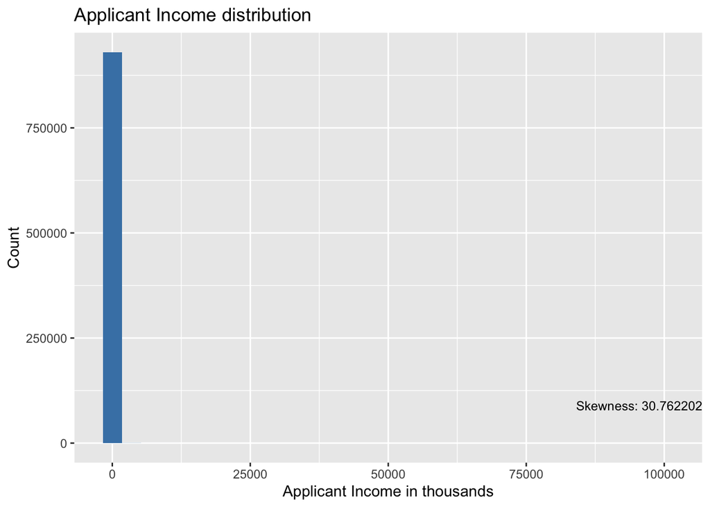

```r
skew <- paste("Skewness:",skewness(hmda_pa_df$applicant_income_000s,na.rm = TRUE))
ggplot(data = hmda_pa_df , aes(x = applicant_income_000s)) + geom_histogram(fill = "steelblue") + labs(title = "Applicant Income distribution" , x = "Applicant Income in thousands" , y = "Count") + annotate("text", x = 100000, y = 90000, size = 3.2,label = skew)
```

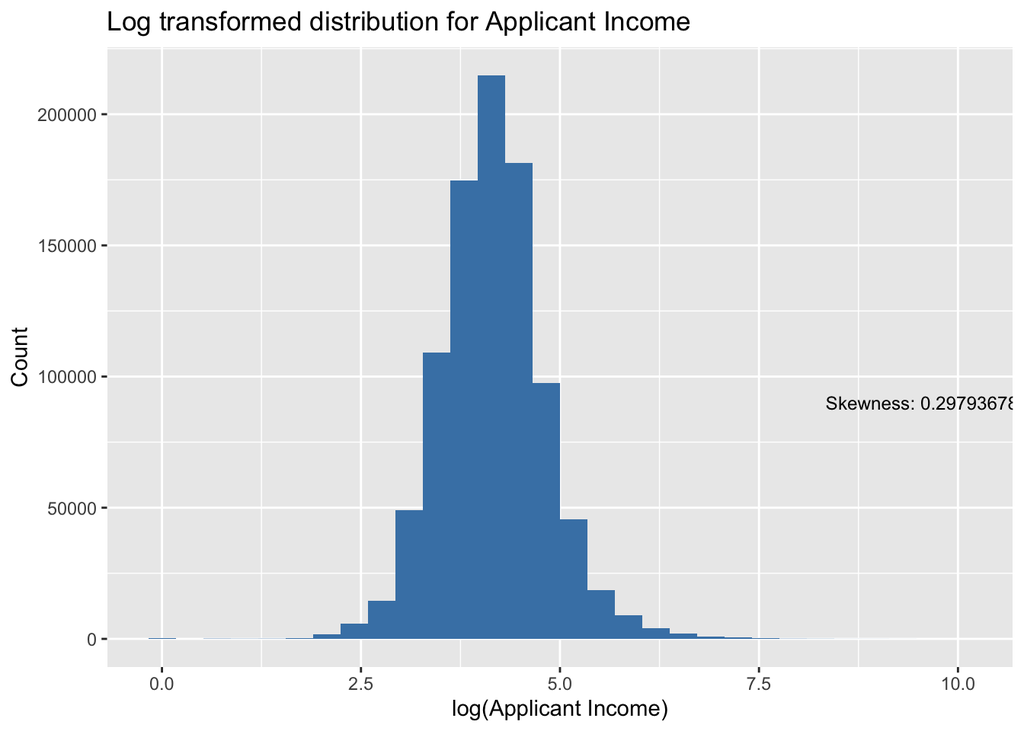

```r
skew <- paste("Skewness:",skewness(log(hmda_pa_df$applicant_income_000s),na.rm=TRUE))
ggplot(data = hmda_pa_df , aes(x = log(applicant_income_000s))) + geom_histogram(fill = "steelblue") + labs(title = "Log transformed distribution for Applicant Income" , x = "log(Applicant Income)", y = 'Count') +annotate("text", x = 10, y = 90000, size = 3.2,label = skew)
```